# Lab 05 - Predicting MHV Change

# Part 3 - Predict MHV Change

## Now select at least three census variables that you feel will be good predictors of change in MHV between 2000 and 2010.

**ANSWER: The variables I chose to predict Median Home Value Growth over the next ten years are: Unemployment Rate, Low English Rate, Female Labor Rate.**

### Load and Clean Data

```r
d_predict <- dMaster

# Create subset, keeping only values we want
d_predict <- select( d_predict, tractid, unemp12, unemp00,
             lep00, lep12, fhh00, fhh12,
             flabf00, flabf12, clf00, ag5up00,
             "mhv.00", "mhv.10", "mhv.change", "mhv.growth",
             cbsa, cbsaname )

# Create new variables
d_predict <-
  d_predict %>%
  mutate( # Below are percent change from 2000 to 2010
          p.unemp.change = 100 * ( unemp12 - unemp00 ) / (unemp00 + 0.01),
          p.lep.change = 100 * ( lep12 - lep00 ) / (lep00 + 0.01),
          p.flabf.change = 100 * ( flabf12 - flabf00 ) / (flabf00 + 0.01),
          # Below is the percent within a population
          unemp.rate00 = 100 * ( unemp00 / ( clf00 + 0.01 )),
          lep.rate00 = 100 * ( lep00 / ( ag5up00 + 0.01 )),
          flabf.rate00 = 100 * ( flabf00 / (clf00 + 0.01 ))
          )

# Remove outliers that came from dividing a large number by 0.01
d_predict[which(d_predict$p.unemp.change %in% boxplot(d_predict$p.unemp.change, plot=FALSE)$out), "p.unemp.change"] <- NA
d_predict[which(d_predict$p.lep.change %in% boxplot(d_predict$p.lep.change, plot=FALSE)$out),"p.lep.change"] <- NA
d_predict[which(d_predict$p.flabf.change %in% boxplot(d_predict$p.flabf.change, plot=FALSE)$out),"p.flabf.change"] <- NA
d_predict[which(d_predict$unemp.rate00 %in% boxplot(d_predict$unemp.rate00, plot=FALSE)$out),"unemp.rate00"] <- NA
d_predict[which(d_predict$lep.rate00 %in% boxplot(d_predict$lep.rate00, plot=FALSE)$out),"lep.rate00"] <- NA
d_predict[which(d_predict$flabf.rate00 %in% boxplot(d_predict$flabf.rate00, plot=FALSE)$out),"flabf.rate00"] <- NA

# Round the entire dataset to 2 digits
is.num <- sapply(d_predict, is.numeric)
d_predict[is.num] <- lapply(d_predict[is.num], round, 2)

head(d_predict)
```

|  | tractid | unemp12 | unemp00 | lep00 | lep12 | fhh00 | fhh12 | flabf00 | flabf12 | clf00 | ag5up00 | mhv.00 | mhv.10 | mhv.change | mhv.growth | cbsa | cbsaname | p.unemp.change | p.lep.change | p.flabf.change | unemp.rate00 | lep.rate00 | flabf.rate00 |
| --- | --- | --- | --- | --- | --- | --- | --- | --- | --- | --- | --- | --- | --- | --- | --- | --- | --- | --- | --- | --- | --- | --- | --- |
| 1 | fips-01-001-020100 | 32 | 46.00 | 0.00 | 0 | 59.00 | 25 | 383.99 | 424 | 871.99 | 1780.98 | 98702.93 | 121500 | 22797.07 | 23.10 | 33860 | Montgomery, AL | -30.43 | 0.00 | 10.42 | 5.28 | 0.00 | 44.04 |
| 2 | fips-01-001-020200 | 134 | 80.00 | 8.00 | 28 | 121.00 | 124 | 392.00 | 560 | 802.00 | 1774.00 | 93935.30 | 130500 | 36564.70 | 38.93 | 33860 | Montgomery, AL | 67.49 | 249.69 | 42.86 | 9.97 | 0.45 | 48.88 |
| 3 | fips-01-001-020300 | 36 | 42.00 | 17.00 | 12 | 118.00 | 108 | 677.00 | 685 | 1456.00 | 3047.00 | 102955.15 | 118700 | 15744.85 | 15.29 | 33860 | Montgomery, AL | -14.28 | -29.39 | 1.18 | 2.88 | 0.56 | 46.50 |
| 4 | fips-01-001-020400 | 206 | 77.00 | 0.00 | 2 | 102.00 | 89 | 1062.00 | 934 | 2191.00 | 4281.00 | 115711.79 | 133500 | 17788.21 | 15.37 | 33860 | Montgomery, AL | 167.51 | NA | -12.05 | 3.51 | 0.00 | 48.47 |
| 5 | fips-01-001-020500 | 201 | 49.35 | 33.03 | 60 | 144.64 | 395 | 1316.80 | 2643 | 2955.17 | 5601.03 | 150236.59 | 174500 | 24263.41 | 16.15 | 33860 | Montgomery, AL | 307.24 | 81.65 | NA | 1.67 | 0.59 | 44.56 |
| 6 | fips-01-001-020600 | 177 | 87.18 | 56.18 | 74 | 123.01 | 167 | 747.78 | 837 | 1583.69 | 3031.78 | 90713.92 | 129600 | 38886.08 | 42.87 | 33860 | Montgomery, AL | 103.03 | 31.71 | 11.93 | 5.50 | 1.85 | 47.22 |

### Create a metro-wide variable for MHV change and growth

```r
# average growth in median home value for the city
d_predict <-
  d_predict %>%
  group_by( cbsaname ) %>%
  mutate( metro.mhv.change = median( mhv.change, na.rm=T ),
             metro.mhv.growth = 100 * median( mhv.growth, na.rm=T ) ) %>%
  ungroup()
```

### Peek at variable’s Histograms for Skews

**We see below that both Unemployment Rate and Low Enlgish Rate have skewed data.**

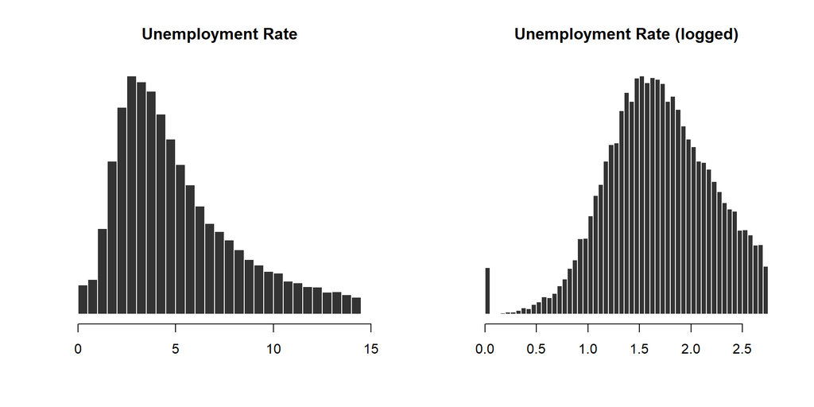

```r
par( mfrow=c(1,2) )

hist( d_predict$unemp.rate00, breaks=50, col="gray20", border="white",
      yaxt="n", xlab="", ylab="", main="Unemployment Rate")
hist( log(d_predict$unemp.rate00+1), breaks=50, col="gray20", border="white",
      yaxt="n", xlab="", ylab="", main="Unemployment Rate (logged)")
```

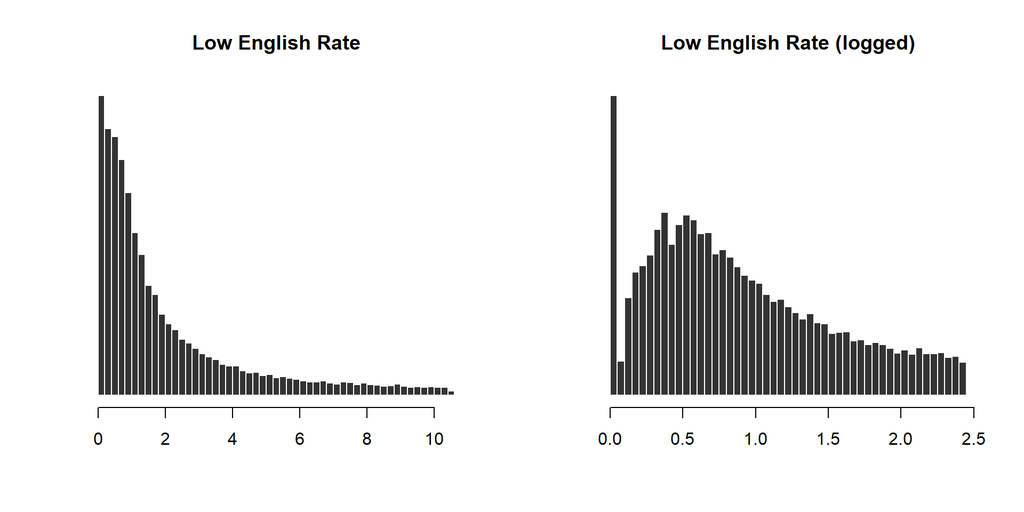

```r
par( mfrow=c(1,2) )

hist( d_predict$lep.rate00, breaks=50, col="gray20", border="white",
      yaxt="n", xlab="", ylab="", main="Low English Rate")
hist( log(d_predict$lep.rate00+1), breaks=50, col="gray20", border="white",
      yaxt="n", xlab="", ylab="", main="Low English Rate (logged)")
```

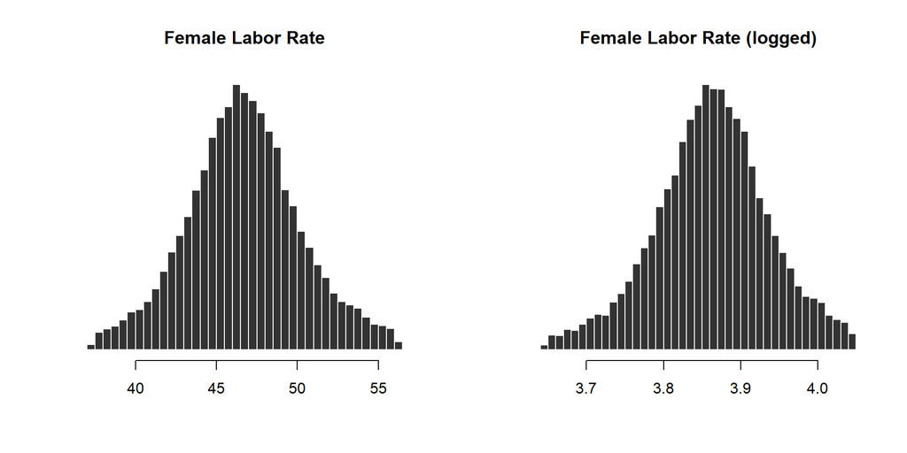

```r
par( mfrow=c(1,2) )

hist( d_predict$flabf.rate00, breaks=50, col="gray20", border="white",
      yaxt="n", xlab="", ylab="", main="Female Labor Rate")
hist( log(d_predict$flabf.rate00+1), breaks=50, col="gray20", border="white",
      yaxt="n", xlab="", ylab="", main="Female Labor Rate (logged)")
```

### Fix Skewed Data

```r
d_predict$unemp.rate00 <- log10( d_predict$unemp.rate00 + 1)
d_predict$lep.rate00 <- log10( d_predict$lep.rate00 + 1)
```

### Check for Multicollinarity

```r
m1 <- lm( mhv.growth ~  unemp.rate00, data=d_predict )
m2 <- lm( mhv.growth ~  lep.rate00, data=d_predict )
m3 <- lm( mhv.growth ~  flabf.rate00, data=d_predict )
m4 <- lm( mhv.growth ~ unemp.rate00 + lep.rate00 + flabf.rate00, data=d_predict )


stargazer( m1, m2, m3, m4,
           type=s.type, digits=2,
           omit.stat = c("rsq","f") )
```

|  | *Dependent variable:* |  |  |  |
| --- | --- | --- | --- | --- |
|  | mhv.growth |  |  |  |
|  | (1) | (2) | (3) | (4) |
| unemp.rate00 | 14.19*** |  |  | -1.39* |
|  | (0.66) |  |  | (0.75) |
| lep.rate00 |  | 17.53*** |  | 17.73*** |
|  |  | (0.54) |  | (0.55) |
| flabf.rate00 |  |  | 0.21*** | 0.56*** |
|  |  |  | (0.04) | (0.05) |
| Constant | 18.44*** | 20.31*** | 19.07*** | -5.88*** |
|  | (0.51) | (0.26) | (1.94) | (2.11) |
| Observations | 55,115 | 51,352 | 55,772 | 47,174 |
| Adjusted R<sup>2</sup> | 0.01 | 0.02 | 0.0005 | 0.03 |
| Residual Std. Error | 33.87 (df = 55113) | 33.21 (df = 51350) | 34.16 (df = 55770) | 31.52 (df = 47170) |
| *Note:* | p<0.1; p<0.05; p<0.01 |  |  |  |

**Summary**

```r
d_predict_edit <- select(d_predict, mhv.growth, unemp.rate00, lep.rate00, flabf.rate00)

summary(d_predict_edit)
```

```
##    mhv.growth      unemp.rate00     lep.rate00     flabf.rate00
##  Min.   :-96.89   Min.   :0.000   Min.   :0.000   Min.   :37.25
##  1st Qu.:  5.74   1st Qu.:0.584   1st Qu.:0.176   1st Qu.:44.48
##  Median : 25.00   Median :0.726   Median :0.334   Median :46.65
##  Mean   : 29.46   Mean   :0.731   Mean   :0.391   Mean   :46.71
##  3rd Qu.: 48.73   3rd Qu.:0.885   3rd Qu.:0.572   3rd Qu.:48.87
##  Max.   :199.74   Max.   :1.190   Max.   :1.061   Max.   :56.22
##  NA's   :766      NA's   :4079    NA's   :7793    NA's   :3485
```

**Cronbach’s Alpha Score**

```r
a_chosen_var <- psych::alpha( d_predict_edit, check.keys=TRUE )$total$std.alpha
a_chosen_var
```

```
## [1] 0.2759227
```

**Correlation Plot**

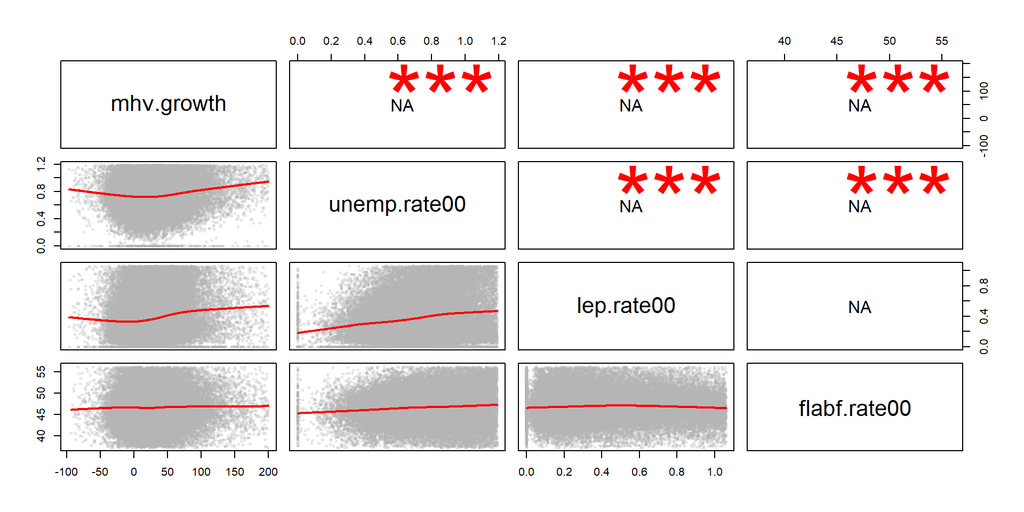

```r
pairs( d_predict_edit, lower.panel=panel.smooth, upper.panel=panel.cor )
```

## Looking at Data as Metro Groups

### First, let’s look at **Unemployment Rate** and it’s effect on MHV Growth within three random cities.

**Scatterplot, choosing three random cities**

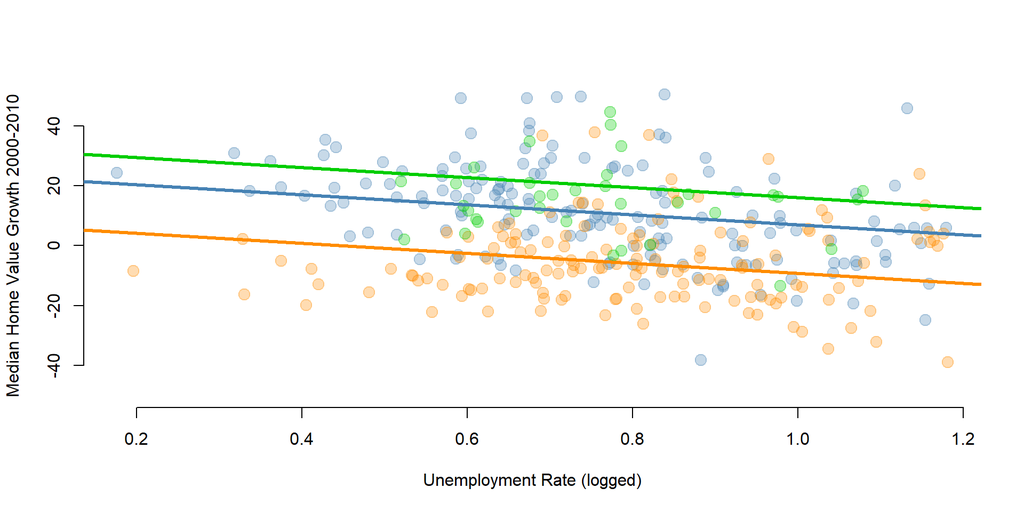

```r
d_grouped <- filter( d_predict, cbsaname %in%
               c("Tyler, TX",
                 "Youngstown-Warren-Boardman, OH-PA",
                 "Syracuse, NY") )

m <- lm( mhv.growth ~ factor(cbsaname) + unemp.rate00 - 1, data=d_grouped )

b0.syracuse   <- m$coefficients[1]
b0.tyler      <- m$coefficients[2]
b0.youngston  <- m$coefficients[3]
b1            <- m$coefficients[4]

palette( c( "steelblue", "green3", "darkorange"  ) )
palette( adjustcolor( palette(), alpha.f = 0.3 ) )

plot( d_grouped$unemp.rate00, d_grouped$mhv.growth,
        pch=19, cex=1.5, bty = "n",
        col=factor(d_grouped$cbsa),
      ylim=c(-50,50),
      xlab="Unemployment Rate (logged)",
      ylab="Median Home Value Growth 2000-2010")

abline( b0.syracuse, b1, col="steelblue", lwd=3 )
abline( b0.tyler, b1, col="green3", lwd=3 )
abline( b0.youngston, b1, col="darkorange", lwd=3 )
```

**Regression Analysis for the Effects of Unemployment Rate on MHV Growth by City.**

```r
m1 <- lm( mhv.growth ~ unemp.rate00 + cbsa, data=d_grouped )

stargazer( m1,
           type=s.type, digits=2,
           omit.stat = c("rsq","f"),
           omit="cbsa" )
```

|  | *Dependent variable:* |
| --- | --- |
|  | mhv.growth |
| unemp.rate00 | -16.72*** |
|  | (4.71) |
| Constant | 23.76*** |
|  | (3.83) |
| Observations | 341 |
| Adjusted R<sup>2</sup> | 0.25 |
| Residual Std. Error | 17.09 (df = 337) |
| *Note:* | p<0.1; p<0.05; p<0.01 |

### Second, let’s look at **Low English Speaking People** and it’s effect on MHV Growth within three random cities.

**Scatterplot, choosing three random cities**

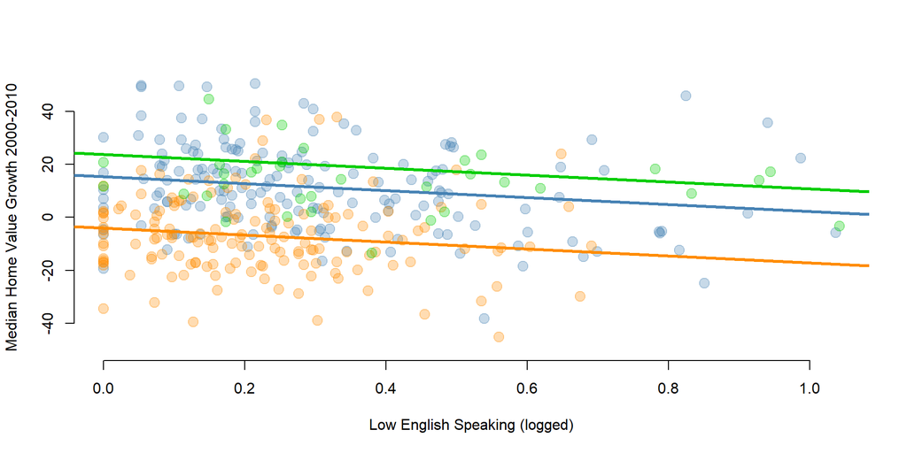

```r
d_grouped <- filter( d_predict, cbsaname %in%
               c("Tyler, TX",
                 "Youngstown-Warren-Boardman, OH-PA",
                 "Syracuse, NY") )

m <- lm( mhv.growth ~ factor(cbsaname) + lep.rate00 - 1, data=d_grouped )

b0.syracuse   <- m$coefficients[1]
b0.tyler      <- m$coefficients[2]
b0.youngston  <- m$coefficients[3]
b1            <- m$coefficients[4]

palette( c( "steelblue", "green3", "darkorange"  ) )
palette( adjustcolor( palette(), alpha.f = 0.3 ) )

plot( d_grouped$lep.rate00, d_grouped$mhv.growth,
        pch=19, cex=1.5, bty = "n",
        col=factor(d_grouped$cbsa),
      ylim=c(-50,50),
      xlab="Low English Speaking (logged)",
      ylab="Median Home Value Growth 2000-2010")

abline( b0.syracuse, b1, col="steelblue", lwd=3 )
abline( b0.tyler, b1, col="green3", lwd=3 )
abline( b0.youngston, b1, col="darkorange", lwd=3 )
```

```r
m2 <- lm( mhv.growth ~ lep.rate00 + cbsa, data=d_grouped )

stargazer( m2,
           type=s.type, digits=2,
           omit.stat = c("rsq","f"),
           omit="cbsa" )
```

|  | *Dependent variable:* |
| --- | --- |
|  | mhv.growth |
| lep.rate00 | -12.98*** |
|  | (4.54) |
| Constant | 15.27*** |
|  | (1.91) |
| Observations | 363 |
| Adjusted R<sup>2</sup> | 0.25 |
| Residual Std. Error | 17.47 (df = 359) |
| *Note:* | p<0.1; p<0.05; p<0.01 |

### Third, let’s look at **Female Labor Force** and it’s effect on MHV Growth within three random cities.

**Scatterplot, choosing three random cities**

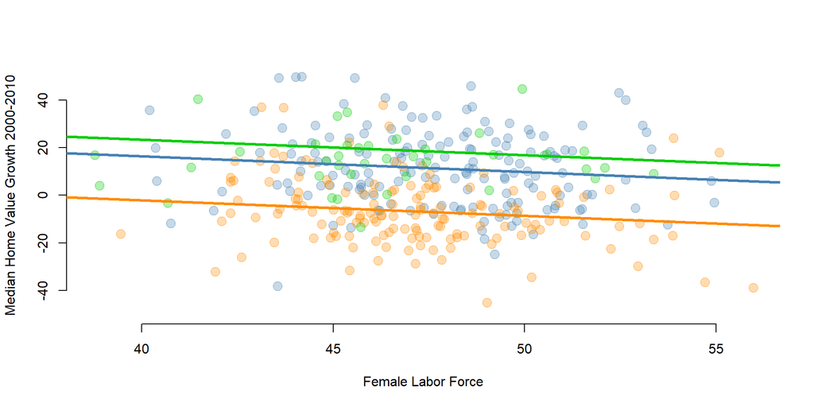

```r
d_grouped <- filter( d_predict, cbsaname %in%
               c("Tyler, TX",
                 "Youngstown-Warren-Boardman, OH-PA",
                 "Syracuse, NY") )

m <- lm( mhv.growth ~ factor(cbsaname) + flabf.rate00 - 1, data=d_grouped )

b0.syracuse   <- m$coefficients[1]
b0.tyler      <- m$coefficients[2]
b0.youngston  <- m$coefficients[3]
b1            <- m$coefficients[4]

palette( c( "steelblue", "green3", "darkorange"  ) )
palette( adjustcolor( palette(), alpha.f = 0.3 ) )

plot( d_grouped$flabf.rate00, d_grouped$mhv.growth,
        pch=19, cex=1.5, bty = "n",
        col=factor(d_grouped$cbsa),
      ylim=c(-50,50),
      xlab="Female Labor Force",
      ylab="Median Home Value Growth 2000-2010")

abline( b0.syracuse, b1, col="steelblue", lwd=3 )
abline( b0.tyler, b1, col="green3", lwd=3 )
abline( b0.youngston, b1, col="darkorange", lwd=3 )
```

**Regression Analysis for the Effects of Female Labor Force on MHV Growth by City.**

```r
m3 <- lm( mhv.growth ~ flabf.rate00 + cbsa, data=d_grouped )

stargazer( m3,
           type=s.type, digits=2,
           omit.stat = c("rsq","f"),
           omit="cbsa" )
```

|  | *Dependent variable:* |
| --- | --- |
|  | mhv.growth |
| flabf.rate00 | -0.66** |
|  | (0.30) |
| Constant | 42.71*** |
|  | (14.47) |
| Observations | 356 |
| Adjusted R<sup>2</sup> | 0.25 |
| Residual Std. Error | 17.38 (df = 352) |
| *Note:* | p<0.1; p<0.05; p<0.01 |

### Finally, let’s run a Regression Analysis using all three variables by city

```r
m4 <- lm( mhv.growth ~ unemp.rate00 + lep.rate00 + flabf.rate00 + cbsa, data=d_grouped )

stargazer( m4,
           type=s.type, digits=2,
           omit.stat = c("rsq","f"),
           omit="cbsa" )
```

|  | *Dependent variable:* |
| --- | --- |
|  | mhv.growth |
| unemp.rate00 | -13.44*** |
|  | (4.93) |
| lep.rate00 | -9.76* |
|  | (5.15) |
| flabf.rate00 | -0.56* |
|  | (0.34) |
| Constant | 50.82*** |
|  | (16.25) |
| Observations | 329 |
| Adjusted R<sup>2</sup> | 0.27 |
| Residual Std. Error | 16.90 (df = 323) |
| *Note:* | p<0.1; p<0.05; p<0.01 |